# SingleCellNet

- シングルセルアノテーションは伝統的に、細胞タイプ特異的マーカーの発現に基づいており、cell identityを定量的に評価することができませんでした。
- この問題を解決しようとする多くの試みにもかかわらず、細胞の分類やアノテーションの方法は、プラットフォームに依存した方法に大きく制限されています。
- 我々の計算ツールである**SingleCellNet（SCN）**は、ランダムフォレストを用いて cross-platform または cross-speciesのデータセットから細胞型特異的な遺伝子ペア群を学習し、シングルセルの分解能でcell identityを定量的に評価することができる。
- ここでは、1) トレーニング 2) クエリ 3) SCNのビジュアライズ機能を紹介します。
- Bulk RNA-seqに対して用いたい場合は、[bulk CellNet](https://github.com/pcahan1/CellNet)を参照してください。

```r
suppressPackageStartupMessages({
    library(singleCellNet)
    library(loomR)
})
```

```r
# Load query data
stPark = utils_loadObject("sampTab_Park_MouseKidney_062118.rda")
expPark = utils_loadObject("expMatrix_Park_MouseKidney_Oct_12_2018.rda")
dim(expPark)
```

1. 16272

2. 43745

```r
genesPark = rownames(expPark)

rm(expPark)
gc()
```

A matrix: 2 × 6 of type dbl

|  | used | (Mb) | gc trigger | (Mb) | max used | (Mb) |
| --- | --- | --- | --- | --- | --- | --- |
| Ncells | 2090447 | 111.7 | 4216927 | 225.3 | 2603981 | 139.1 |
| Vcells | 3976419 | 30.4 | 71158064 | 542.9 | 72522785 | 553.4 |

```r
# Load the training data
expTMraw = utils_loadObject("expMatrix_TM_Raw_Oct_12_2018.rda")
dim(expTMraw)
```

1. 23433

2. 24936

```r
stTM = utils_loadObject("sampTab_TM_053018.rda")
dim(stTM)
```

1. 24936

2. 17

```r
stTM <- droplevels(stTM)
```

```r
# Find genes in common to the data sets and limit analysis to these
commonGenes = intersect(rownames(expTMraw), genesPark)
length(commonGenes)
```

13831

```r
expTMraw = expTMraw[commonGenes,]
```

```r
# Split for training and assessment, and transform training data
set.seed(100) #can be any random seed number
stList = splitCommon(sampTab=stTM, ncells=100, dLevel="newAnn")
stTrain = stList[[1]]
expTrain = expTMraw[,rownames(stTrain)]
```

```
alveolar macrophage : Category alveolar macrophage has 62 samples. Note this category has a samller number than ncells. 62
B cell : 3134
bladder urothelial cell : 759
bladder_mesenchymal : 859
cardiac muscle cell : Category cardiac muscle cell has 60 samples. Note this category has a samller number than ncells. 60
cardiac_fibroblast : 222
chondrocyte-like : 165
endocardial cell : Category endocardial cell has 52 samples. Note this category has a samller number than ncells. 52
endothelial cell : 1890
erythroblast : 152
erythrocyte : Category erythrocyte has 74 samples. Note this category has a samller number than ncells. 74
granulocyte : 520
hematopoietic precursor cell : 117
hepatocyte : 882
keratinocyte : 1203
kidney capillary endothelial cell : 117
kidney proximal straight tubule epithelial cell : 618
kidney_duct_epithelial : 355
late pro-B cell : 141
limb_mesenchymal : 540
luminal epithelial cell of mammary gland : 137
lung_mammary_stromal : 2072
macrophage : 1340
mammary_basal_cell : 115
monocyte : 370
natural killer cell : 600
neuroendocrine cell : 282
skeletal muscle satellite cell : 190
T cell : 1823
tongue_basal_cell : 1726
trachea_epithelial : 434
trachea_mesenchymal : 3925
```

## Train the classifier

- If you increase nTopGenes and nTopGenePairs, you may get a even better classifier performance on query data!

```r
system.time(class_info <- scn_train(stTrain = stTrain,
                                    expTrain = expTrain,
                                    nTopGenes = 10,
                                    nRand = 70,
                                    nTrees = 1000,
                                    nTopGenePairs = 25,
                                    dLevel = "newAnn",
                                    colName_samp = "cell")
           )
```

```
Sample table has been prepared
Expression data has been normalized
Finding classification genes
Done testing
There are  484  classification genes
Finding top pairs
nPairs =  190  for  alveolar macrophage
nPairs =  190  for  B cell
nPairs =  190  for  bladder urothelial cell
nPairs =  190  for  bladder_mesenchymal
nPairs =  190  for  cardiac muscle cell
nPairs =  190  for  cardiac_fibroblast
nPairs =  190  for  chondrocyte-like
nPairs =  190  for  endocardial cell
nPairs =  190  for  endothelial cell
nPairs =  190  for  erythroblast
nPairs =  190  for  erythrocyte
nPairs =  190  for  granulocyte
nPairs =  190  for  hematopoietic precursor cell
nPairs =  190  for  hepatocyte
nPairs =  190  for  keratinocyte
nPairs =  190  for  kidney capillary endothelial cell
nPairs =  190  for  kidney proximal straight tubule epithelial cell
nPairs =  190  for  kidney_duct_epithelial
nPairs =  190  for  late pro-B cell
nPairs =  190  for  limb_mesenchymal
nPairs =  190  for  luminal epithelial cell of mammary gland
nPairs =  190  for  lung_mammary_stromal
nPairs =  190  for  macrophage
nPairs =  190  for  mammary_basal_cell
nPairs =  190  for  monocyte
nPairs =  190  for  natural killer cell
nPairs =  190  for  neuroendocrine cell
nPairs =  190  for  skeletal muscle satellite cell
nPairs =  190  for  T cell
nPairs =  190  for  tongue_basal_cell
nPairs =  190  for  trachea_epithelial
nPairs =  190  for  trachea_mesenchymal
There are 797 top gene pairs
Finished pair transforming the data
Number of missing genes  0
All Done
```

```
   user  system elapsed
493.875  30.265 524.141
```

## Apply to held out data

```r
#validate data
stTestList = splitCommon(sampTab=stList[[2]], ncells=100, dLevel="newAnn") #normalize validation data so that the assessment is as fair as possible
stTest = stTestList[[1]]
expTest = expTMraw[commonGenes,rownames(stTest)]

#predict
classRes_val_all = scn_predict(cnProc=class_info[['cnProc']], expDat=expTest, nrand = 50)
```

```
alveolar macrophage : Category alveolar macrophage has 3 samples. Note this category has a samller number than ncells. 3
B cell : 3034
bladder urothelial cell : 659
bladder_mesenchymal : 759
cardiac muscle cell : Category cardiac muscle cell has 3 samples. Note this category has a samller number than ncells. 3
cardiac_fibroblast : 122
chondrocyte-like : Category chondrocyte-like has 65 samples. Note this category has a samller number than ncells. 65
endocardial cell : Category endocardial cell has 3 samples. Note this category has a samller number than ncells. 3
endothelial cell : 1790
erythroblast : Category erythroblast has 52 samples. Note this category has a samller number than ncells. 52
erythrocyte : Category erythrocyte has 3 samples. Note this category has a samller number than ncells. 3
granulocyte : 420
hematopoietic precursor cell : Category hematopoietic precursor cell has 17 samples. Note this category has a samller number than ncells. 17
hepatocyte : 782
keratinocyte : 1103
kidney capillary endothelial cell : Category kidney capillary endothelial cell has 17 samples. Note this category has a samller number than ncells. 17
kidney proximal straight tubule epithelial cell : 518
kidney_duct_epithelial : 255
late pro-B cell : Category late pro-B cell has 41 samples. Note this category has a samller number than ncells. 41
limb_mesenchymal : 440
luminal epithelial cell of mammary gland : Category luminal epithelial cell of mammary gland has 37 samples. Note this category has a samller number than ncells. 37
lung_mammary_stromal : 1972
macrophage : 1240
mammary_basal_cell : Category mammary_basal_cell has 15 samples. Note this category has a samller number than ncells. 15
monocyte : 270
natural killer cell : 500
neuroendocrine cell : 182
skeletal muscle satellite cell : Category skeletal muscle satellite cell has 90 samples. Note this category has a samller number than ncells. 90
T cell : 1723
tongue_basal_cell : 1626
trachea_epithelial : 334
trachea_mesenchymal : 3825
Loaded in the cnProc
All Done
```

## Assess classifier

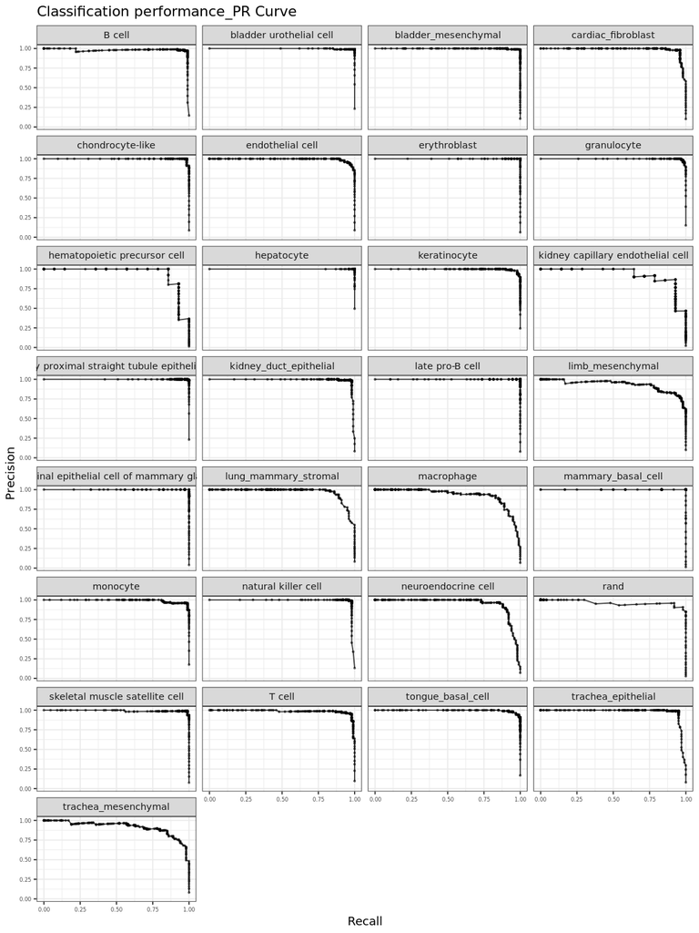

```r
tm_heldoutassessment = assess_comm(ct_scores = classRes_val_all,
                                   stTrain = stTrain,
                                   stQuery = stTest,
                                   dLevelSID = "cell",
                                   classTrain = "newAnn",
                                   classQuery = "newAnn",
                                   nRand = 50)

options(repr.plot.width = 9, repr.plot.height = 12)
plot_PRs(tm_heldoutassessment)
```

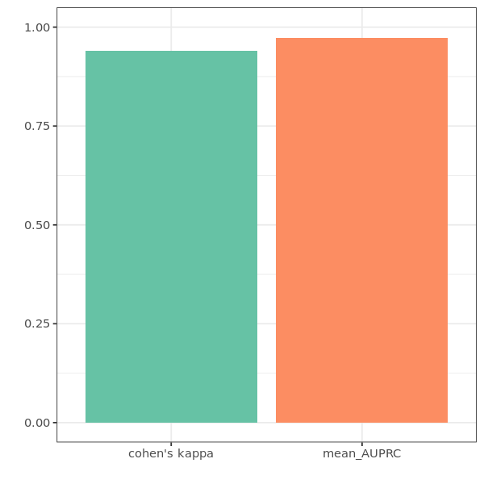

```r
options(repr.plot.width = 5, repr.plot.height = 5)
plot_metrics(tm_heldoutassessment)
```

## Classification result heatmap

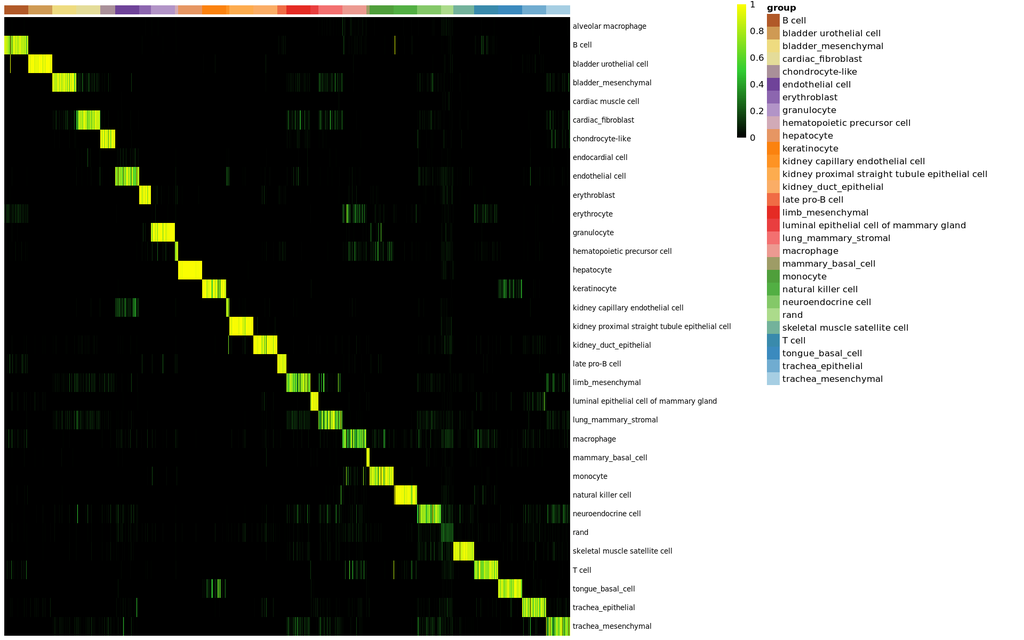

```r
#Create a name vector label used later in classification heatmap where the values are cell types/ clusters and names are the sample names

nrand = 50
sla = as.vector(stTest$newAnn)
names(sla) = as.vector(stTest$cell)
slaRand = rep("rand", nrand)
names(slaRand) = paste("rand_", 1:nrand, sep='')
sla = append(sla, slaRand) #include in the random cells profile created

options(repr.plot.width = 16, repr.plot.height = 10)
sc_hmClass(classMat = classRes_val_all,grps = sla, max=300, isBig=TRUE)
```

## Attribution plot

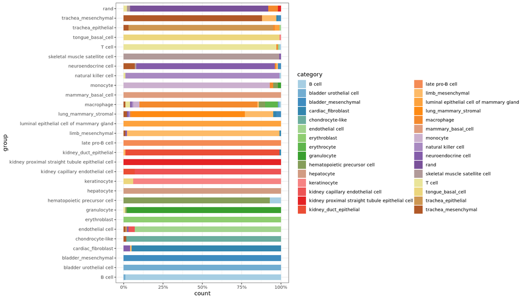

```r
options(repr.plot.width = 14, repr.plot.height = 8)
plot_attr(classRes=classRes_val_all, sampTab=stTest, nrand=nrand, dLevel="newAnn", sid="cell")
```

### Viusalize average top pairs genes expression for training data

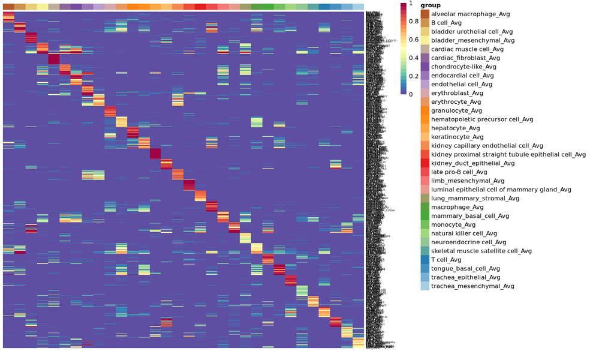

```r
gpTab = compareGenePairs(query_exp = expTest,
                         training_exp = expTrain,
                         training_st = stTrain,
                         classCol = "newAnn",
                         sampleCol = "cell",
                         RF_classifier = class_info$cnProc$classifier,
                         numPairs = 20,
                         trainingOnly= TRUE)

train = findAvgLabel(gpTab = gpTab, stTrain = stTrain, dLevel = "newAnn")

hm_gpa_sel(gpTab, genes = class_info$cnProc$xpairs, grps = train, maxPerGrp = 50)
```

## Apply to Park et al query data

```r
expPark = utils_loadObject("expMatrix_Park_MouseKidney_Oct_12_2018.rda")

nqRand = 50
system.time(crParkall <- scn_predict(class_info[['cnProc']],
                                     expPark,
                                     nrand = nqRand)
           )
```

```
Loaded in the cnProc
All Done
```

```
   user  system elapsed
 59.836   3.368  63.203
```

```r
sgrp = as.vector(stPark$description1)
names(sgrp) = as.vector(stPark$sample_name)
grpRand =rep("rand", nqRand)
names(grpRand) = paste("rand_", 1:nqRand, sep='')
sgrp = append(sgrp, grpRand)
```

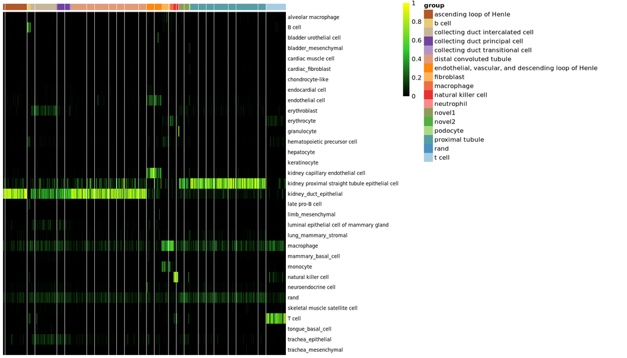

```r
# heatmap classification result
sc_hmClass(crParkall, sgrp, max=5000, isBig=TRUE, cCol=F, font=8)
```

### Classification annotation assignment

```r
# This classifies a cell with  the catgory with the highest classification score or higher than a classification score threshold of your choosing.
# The annotation result can be found in a column named category in the query sample table.

stPark <- get_cate(classRes = crParkall,
                   sampTab = stPark,
                   dLevel = "description1",
                   sid = "sample_name",
                   nrand = nqRand)
```

### Classification result violin plot

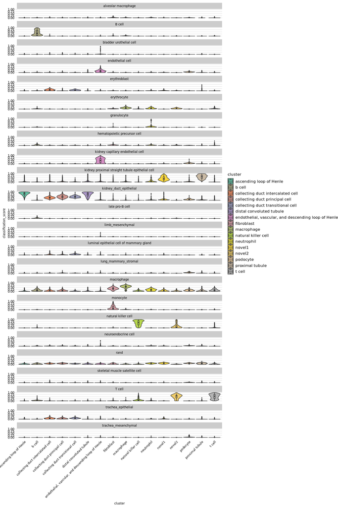

```r
options(repr.plot.width = 12, repr.plot.height = 18)
sc_violinClass(sampTab = stPark,
               classRes = crParkall,
               sid = "sample_name",
               dLevel = "description1",
               addRand = nqRand)
```

### Skyline plot of classification results

```
number of random samples:  50
```

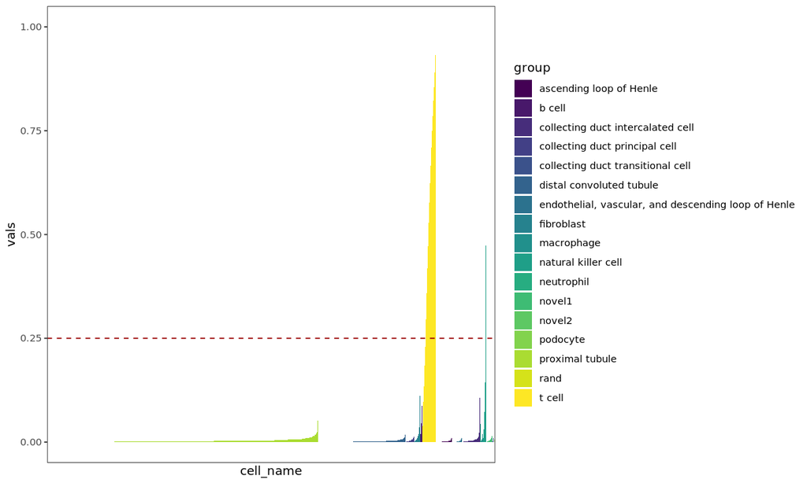

```r
library(viridis)
options(repr.plot.width = 10, repr.plot.height = 6)
stKid2 = addRandToSampTab(crParkall, stPark, "description1", "sample_name")
skylineClass(crParkall, "T cell", stKid2, "description1",.25, "sample_name")
```

## Cross-species classification

### Load the human query data

```r
stQuery = utils_loadObject("stDat_beads_mar22.rda")
expQuery = utils_loadObject("6k_beadpurfied_raw.rda") # use Matrix if RAM low
dim(expQuery)
```

1. 32643

2. 6000

```r
stTM = utils_loadObject("sampTab_TM_053018.rda")
expTMraw = utils_loadObject("expMatrix_TM_Raw_Oct_12_2018.rda") # reload training
```

```r
oTab = utils_loadObject("human_mouse_genes_Jul_24_2018.rda")
dim(oTab)
```

1. 16688

2. 3

```r
aa = csRenameOrth(expQuery, expTMraw, oTab)
expQueryOrth = aa[['expQuery']]
expTrainOrth = aa[['expTrain']]
```

```
query genes in ortholog table =  15532
training genes in ortholog table and query data =  14550
```

### Limit anlaysis to a subset of the TM cell types

```r
cts = c("B cell",  "cardiac muscle cell", "endothelial cell", "erythroblast", "granulocyte", "hematopoietic precursor cell", "late pro-B cell", "limb_mesenchymal", "macrophage", "mammary_basal_cell", "monocyte", "natural killer cell", "T cell", "trachea_epithelial", "trachea_mesenchymal")

stTM2 = filter(stTM, newAnn %in% cts)
stTM2 = droplevels(stTM2)
rownames(stTM2) = as.vector(stTM2$cell) # filter strips rownames

expTMraw2 = expTrainOrth[,rownames(stTM2)]
dim(expTMraw2)
```

1. 14550

2. 15161

### Train Classifier

```r
stList = splitCommon(stTM2, ncells=100, dLevel="newAnn")
stTrain = stList[[1]]
expTrain = expTMraw2[,rownames(stTrain)]
```

```
B cell : 3134
cardiac muscle cell : Category cardiac muscle cell has 60 samples. Note this category has a samller number than ncells. 60
endothelial cell : 1890
erythroblast : 152
granulocyte : 520
hematopoietic precursor cell : 117
late pro-B cell : 141
limb_mesenchymal : 540
macrophage : 1340
mammary_basal_cell : 115
monocyte : 370
natural killer cell : 600
T cell : 1823
trachea_epithelial : 434
trachea_mesenchymal : 3925
```

```r
system.time(class_info2 <- scn_train(stTrain = stTrain,
                                     expTrain = expTrain,
                                     nTopGenes = 10,
                                     nRand = 70,
                                     nTrees = 1000,
                                     nTopGenePairs = 25,
                                     dLevel = "newAnn",
                                     colName_samp = "cell"))
```

```
Sample table has been prepared
Expression data has been normalized
Finding classification genes
Done testing
There are  241  classification genes
Finding top pairs
nPairs =  190  for  B cell
nPairs =  190  for  cardiac muscle cell
nPairs =  190  for  endothelial cell
nPairs =  190  for  erythroblast
nPairs =  190  for  granulocyte
nPairs =  190  for  hematopoietic precursor cell
nPairs =  190  for  late pro-B cell
nPairs =  190  for  limb_mesenchymal
nPairs =  190  for  macrophage
nPairs =  190  for  mammary_basal_cell
nPairs =  190  for  monocyte
nPairs =  190  for  natural killer cell
nPairs =  190  for  T cell
nPairs =  190  for  trachea_epithelial
nPairs =  190  for  trachea_mesenchymal
There are 375 top gene pairs
Finished pair transforming the data
Number of missing genes  0
All Done
```

```
   user  system elapsed
 64.023  11.540  75.564
```

### Apply to held out data

```r
#validate data
stTestList = splitCommon(stList[[2]], ncells=100, dLevel="newAnn")
stTest = stTestList[[1]]
expTest = expTMraw2[,rownames(stTest)]

#predict
system.time(classRes_val_all2 <- scn_predict(class_info2[['cnProc']], expTest, nrand = 50))
```

```
B cell : 3034
cardiac muscle cell : Category cardiac muscle cell has 3 samples. Note this category has a samller number than ncells. 3
endothelial cell : 1790
erythroblast : Category erythroblast has 52 samples. Note this category has a samller number than ncells. 52
granulocyte : 420
hematopoietic precursor cell : Category hematopoietic precursor cell has 17 samples. Note this category has a samller number than ncells. 17
late pro-B cell : Category late pro-B cell has 41 samples. Note this category has a samller number than ncells. 41
limb_mesenchymal : 440
macrophage : 1240
mammary_basal_cell : Category mammary_basal_cell has 15 samples. Note this category has a samller number than ncells. 15
monocyte : 270
natural killer cell : 500
T cell : 1723
trachea_epithelial : 334
trachea_mesenchymal : 3825
Loaded in the cnProc
All Done
```

```
   user  system elapsed
  0.680   0.040   0.721
```

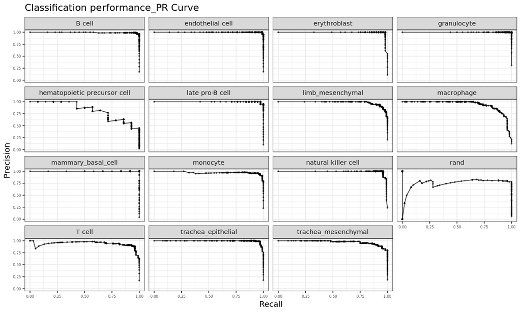

```r
### Assess classifier
tm_heldoutassessment = assess_comm(ct_scores = classRes_val_all2,
                                   stTrain = stTrain,
                                   stQuery = stTest,
                                   dLevelSID = "cell",
                                   classTrain = "newAnn",
                                   classQuery = "newAnn",
                                   nRand = 50)

plot_PRs(tm_heldoutassessment)
```

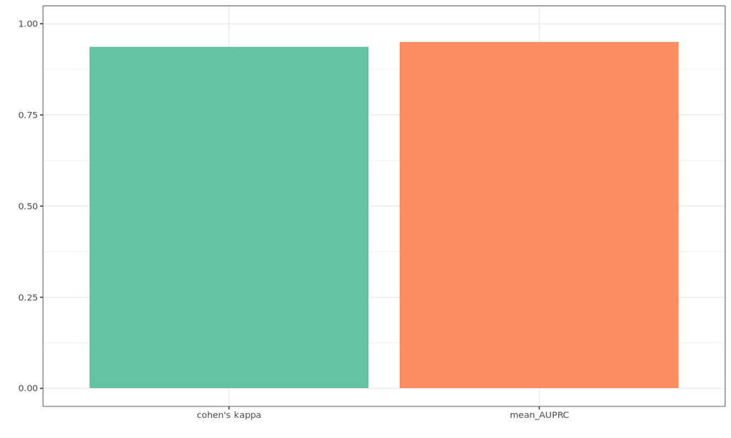

```r
plot_metrics(tm_heldoutassessment)
```

### Classification result heatmap

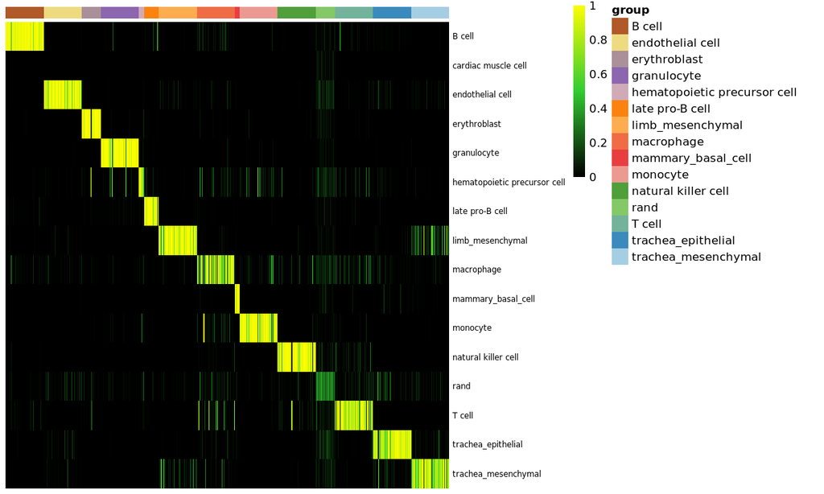

```r
nrand=50
sla = as.vector(stTest$newAnn)
names(sla) = as.vector(stTest$cell)
slaRand = rep("rand", nrand)
names(slaRand) = paste("rand_", 1:nrand, sep='')
sla = append(sla, slaRand)

# heatmap classification result
sc_hmClass(classRes_val_all2, sla, max=300, font=7, isBig=TRUE)
```

### Attribute plot

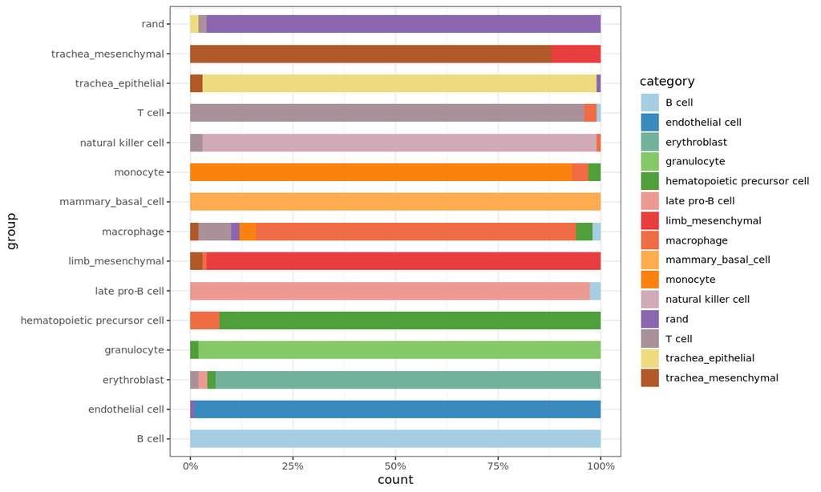

```r
plot_attr(classRes_val_all2, stTest, nrand=nrand, dLevel="newAnn", sid="cell")
```

### Apply to human query data

```r
stQuery$description = as.character(stQuery$description)
stQuery[which(stQuery$description == "NK cell"), "description"] = "natural killer cell"

nqRand = 50
system.time(crHS <- scn_predict(class_info2[['cnProc']], expQueryOrth, nrand=nqRand))
```

```
Loaded in the cnProc
All Done
```

```
   user  system elapsed
  1.703   0.204   1.908
```

### Assess classifier with external dataset

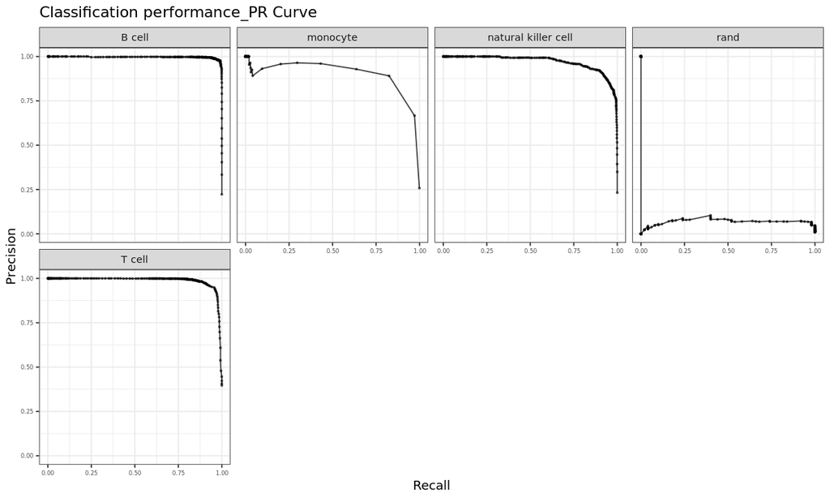

```r
tm_pbmc_assessment = assess_comm(ct_scores = crHS,
                                 stTrain = stTrain,
                                 stQuery = stQuery,
                                 classTrain = "newAnn",
                                 classQuery="description",
                                 dLevelSID="sample_name")
plot_PRs(tm_pbmc_assessment)
```

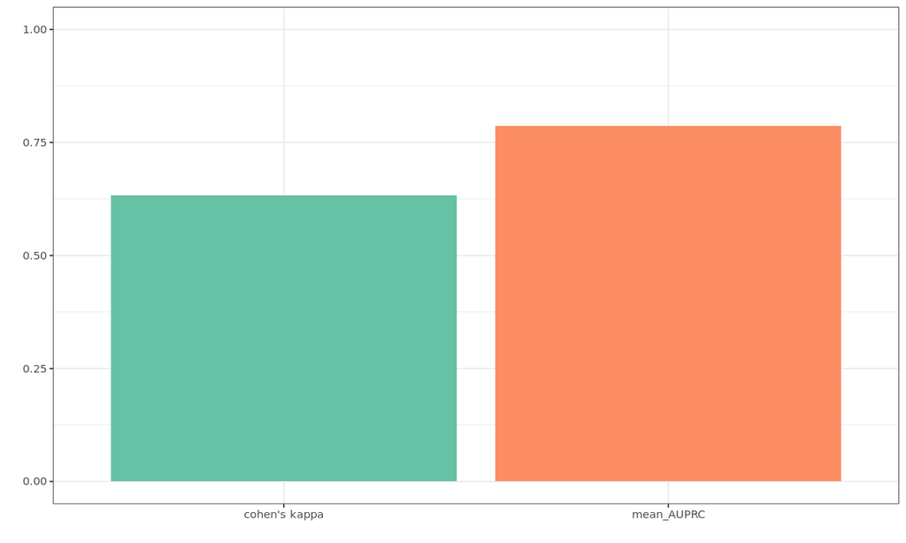

```r
plot_metrics(tm_pbmc_assessment)
```

### Classification result heatmap

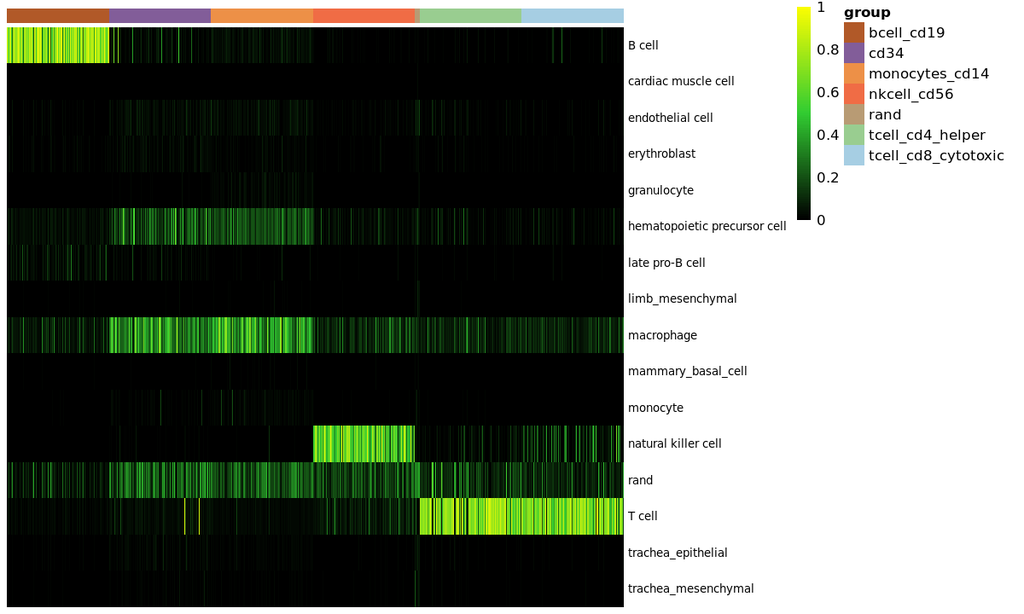

```r
sgrp = as.vector(stQuery$prefix)
names(sgrp) = as.vector(stQuery$sample_name)
grpRand = rep("rand", nqRand)
names(grpRand) = paste("rand_", 1:nqRand, sep='')
sgrp = append(sgrp, grpRand)

sc_hmClass(crHS, sgrp, max=5000, isBig=TRUE, cCol=F, font=8)
```

Note that the macrophage category seems to be promiscuous in the mouse held out data, too.

### Classification violin plot

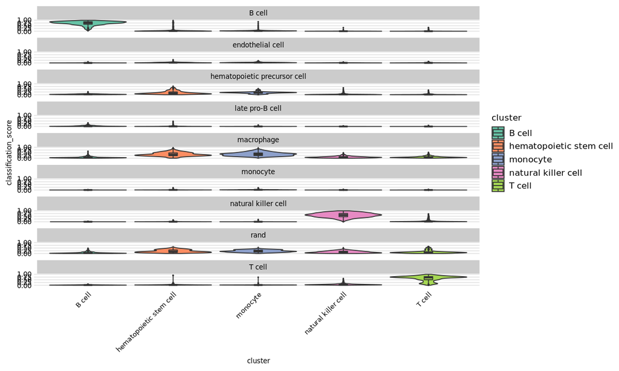

```r
sc_violinClass(sampTab = stQuery, classRes = crHS, sid = "sample_name", dLevel = "description")
```

### Classification violin plot with adjusted width

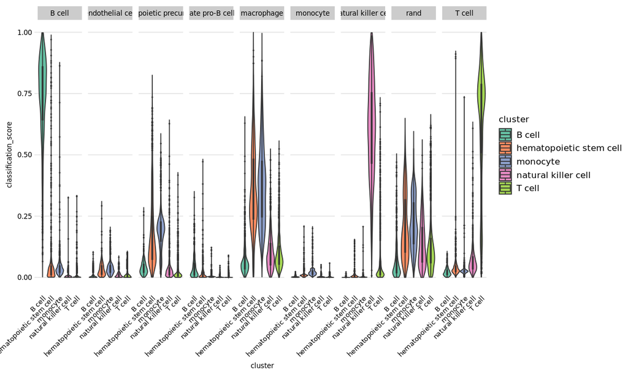

```r
sc_violinClass(sampTab = stQuery,classRes = crHS, sid = "sample_name", dLevel = "description", ncol = 12)
```

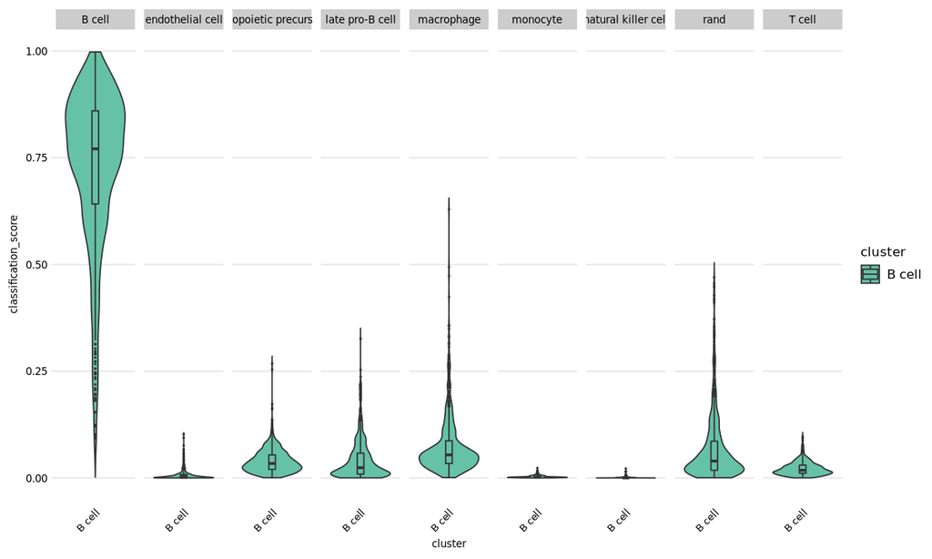

```r
### Classification violin plot with selected cluster

sc_violinClass(stQuery, crHS, sid = "sample_name", dLevel = "description", ncol = 12, sub_cluster = "B cell")
```

### Attribution plot

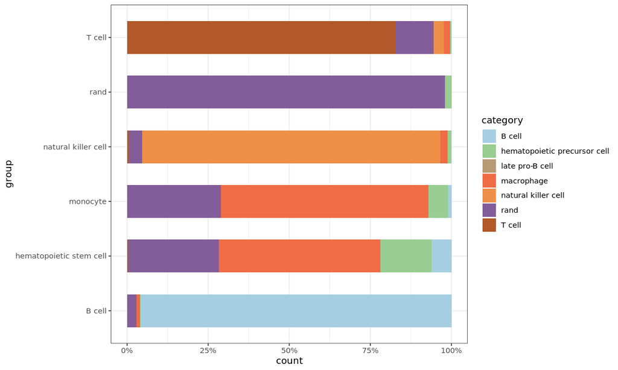

```r
plot_attr(crHS, stQuery, nrand=nqRand, sid="sample_name", dLevel="description")
```

### Attribution plot with subcluster focus

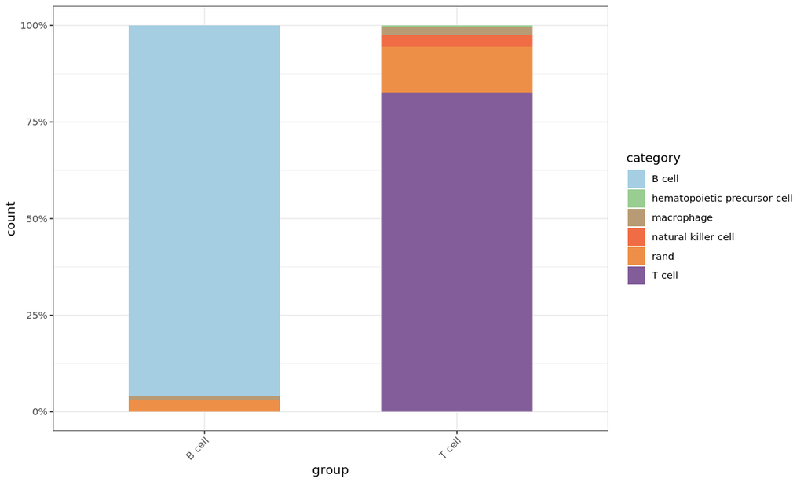

```r
plot_attr(sampTab = stQuery,
          classRes = crHS,
          sid = "sample_name",
          dLevel = "description",
          nrand = 50,
          sub_cluster = c("B cell", "T cell"))
```

### Heatmap top pairs genes for training sample average

```r
system.time(gpTab2 <- compareGenePairs(query_exp = expQueryOrth,
                                       training_exp = expTrainOrth,
                                       training_st = stTrain,
                                       classCol = "newAnn",
                                       sampleCol = "cell",
                                       RF_classifier = class_info2$cnProc$classifier,
                                       numPairs = 20,
                                       trainingOnly = FALSE)
           )
```

```
[1] "All Good"
```

```
   user  system elapsed
124.608   1.540 126.148
```

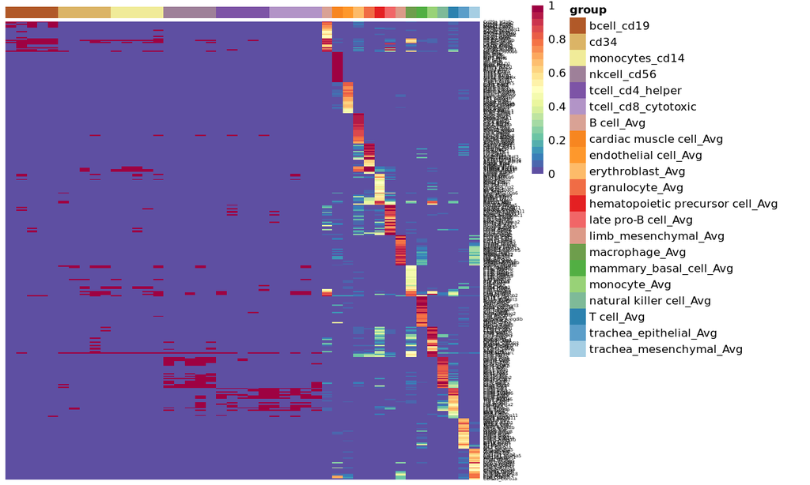

```r
sgrp = as.vector(stQuery$prefix)
names(sgrp) = rownames(stQuery)
train2 = findAvgLabel(gpTab2, stTrain = stTrain, dLevel = "newAnn")
sgrp = append(sgrp, train2)

hm_gpa_sel(gpTab2, genes = class_info2$cnProc$xpairs, grps = sgrp, maxPerGrp = 5)
```

### UMAP by category

```r
system.time(umPrep_HS<-prep_umap_class(crHS, stQuery, nrand=nqRand, dLevel="description", sid="sample_name", topPC=5))
```

```
PCA
UMAP
done
```

```
   user  system elapsed
 31.224   0.276  31.528
```

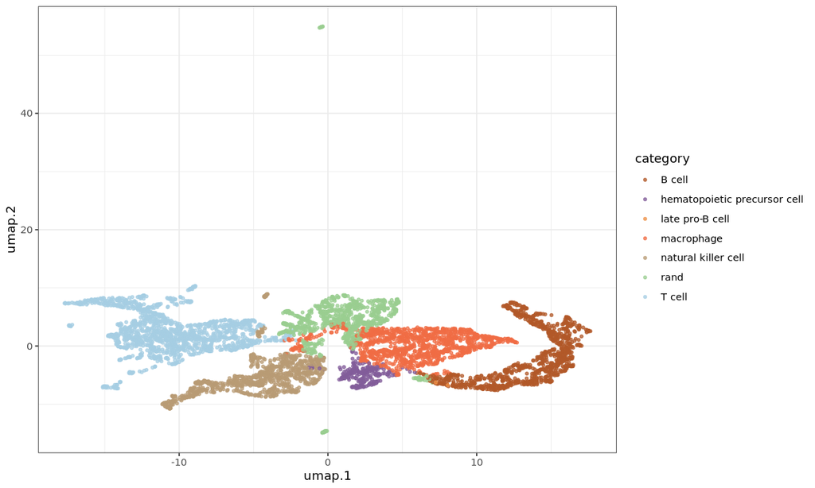

```r
plot_umap(umPrep_HS)
```

## How to integrate loom file to SCN

```r
lfile = loadLoomExpCluster("pbmc_6k.loom", cellNameCol = "obs_names", xname = "description")
stQuery = lfile$sampTab
dim(stQuery)
```

1. 6000

2. 2

```r
expQuery = lfile$expDat
dim(expQuery)
```

1. 32643

2. 6000

```r
#exp_type options can be: counts, data, and scale.data if they are available in your sce object

scefile = extractSCE(sce_object, exp_slot_name = "counts")
sampTab = scefile$sampTab
expDat = scefile$expDat
```

[output not shown]

```r
#exp_type options can be: counts, normcounts, and logcounts, if they are available in your sce object
seuratfile = extractSeurat(seurat_object, exp_slot_name = "counts")
sampTab = seuratfile$sampTab
expDat = seuratfile$expDat
```